# QMSS G5072 Homework 1

Anouch Missirian

2017-09-14

# Using Github and RMarkdown

This short exercise is meant to make sure that all students have setup their Github account correctly, are able to write a simple RMarkdown document, and can submit their solution to their own private repository on Github.

## R Markdown

### 1. Create R Markdown document

From the instructions, you should have created a bare bones RMarkdown file that outputs a `.html` file and a GitHub flavored `.md` document. If you have not, the instructions for this homework itself have the configuration you are looking for.

Make sure to insert a YAML Header with title, author and date at the top of your .Rmd script.

### 2. Get some data

(Get some data from our friends at fivethirtyeight.com.)

I chose the `trump_twitter` dataset. It consists in “The World’s Favorite Donald Trump Tweets” (based on the number of retweets?), i.e. 448 tweets posted by the Twitter account @realDonaldTrump between August 1st, 2015 and August 16th, 2016, and that were used in the FiveThirtyEight article [“The World’s Favorite Donald Trump Tweets”](https://fivethirtyeight.com/features/the-worlds-favorite-donald-trump-tweets/) (06/21/2016).

(Manually create a small table for your dataframe with two columns: variable name and variable description. Include a few variables in the table.)

```r
variables <- data.frame(c("id", "created_at", "text"),c("unique identifier", "date created", "contents of the tweet"))
names(variables) <- c("name", "description")
variables
```

```
##         name           description
## 1         id     unique identifier
## 2 created_at          date created
## 3       text contents of the tweet
```

### 3. Show the data

```
##        id              created_at                      text
##  Min.   :6.275e+17   Min.   :2015-08-01 17:10:49   Length:448
##  1st Qu.:6.489e+17   1st Qu.:2015-09-29 15:04:27   Class :character
##  Median :6.614e+17   Median :2015-11-03 04:05:50   Mode  :character
##  Mean   :6.682e+17   Mean   :2015-11-21 22:44:43
##  3rd Qu.:6.824e+17   3rd Qu.:2015-12-31 06:23:51
##  Max.   :7.656e+17   Max.   :2016-08-16 19:22:57
```

Using the command `datatable` from the package [`DT`](http://rstudio.github.io/DT/) let’s look at an *interactive* table of the data *in* the document:

|  | id | created_at | text |
| --- | --- | --- | --- |
| 1 | 7.65629939811021e+17 | 2016-08-16T19:22:57Z | It's just a 2-point race, Clinton 38%, Trump 36%' https://t.co/EzDzJ4EzIN |
| 2 | 7.58731880183194e+17 | 2016-07-28T18:32:31Z | "@LallyRay: Poll: Donald Trump Sees 17-Point Positive Swing in Two Weeks - Breitbart https://t.co/bVAj52fA3Y @realdonaldtrump" Great! |
| 3 | 7.58350470402408e+17 | 2016-07-27T17:16:56Z | Great new poll - thank you! #MakeAmericaGreatAgain https://t.co/mXovx0TLPC |
| 4 | 7.57577508346888e+17 | 2016-07-25T14:05:27Z | Great POLL numbers are coming out all over. People don't want another four years of Obama, and Crooked Hillary would be even worse. #MAGA |
| 5 | 7.53603401854882e+17 | 2016-07-14T14:53:46Z | Another new poll. Thank you for your support! Join the MOVEMENT today! #ImWithYou https://t.co/3KWOl2ibaW https://t.co/miT4atHxQz |
| 6 | 7.53580257895211e+17 | 2016-07-14T13:21:48Z | Great new poll- thank you America! #Trump2016 #ImWithYou https://t.co/aVH9c5QRwc |
| 7 | 7.53353259411055e+17 | 2016-07-13T22:19:48Z | Despite spending $500k a day on TV ads alone #CrookedHillary falls flat in nationwide @QuinnipiacPoll. Having ZERO impact. Sad!! |
| 8 | 7.52618593196597e+17 | 2016-07-11T21:40:30Z | Great poll- Florida! Thank you! https://t.co/4FuPpL5WOM |
| 9 | 7.51889266934964e+17 | 2016-07-09T21:22:25Z | New poll - thank you! #Trump2016 https://t.co/Mi87Vmw06H https://t.co/WmqvcYG4r3 |
| 10 | 7.48163921383723e+17 | 2016-06-29T14:39:13Z | New Q poll out- we are going to win the whole deal- and MAKE AMERICA GREAT AGAIN! #Trump2016 https://t.co/dL5ahNcwZb |

[output cut: 438 more lines]

Let’s now add another *non-interactive* table using the `kable` function in the `knitr` package, and show the first ten rows of our data:

‘trump_tweets’ data set: the first 10 rows

[output not shown]

*Nota:* the “#” in the tweets set the table off (but not always? cf. line 4), and I couldn’t find a way to fix it in `kable` without tampering with the data. Thoughts?

### 4. Add some Latex formulas

The FiveThirtyEight article doesn’t really suggest the mechanism underlying the tweet generation process (compares usage of Twitter among presidential hopefuls), but [Planet Money](http://www.npr.org/2017/04/13/523709894/using-sentiment-analysis-to-understand-trumps-tweets) relates that those tweets may have effects on company valuation on the stock exchange, i.e.:
$$Stock_{it} = f(Valence_{it})$$
with $i$ the company, $t$ the time (month). $Valence$ is an index ($\in [-1,1]$) resulting from the sentiment analysis of a given tweet. More specifically, the functional form could be of the type: $\Delta Stock_{it} = \beta\times Valence_{it}$, $\beta\in\mathbb{R}$, $\Delta Stock$ the variation in the value of the company between $t=0$ and $t$.

### 5. Add a plot

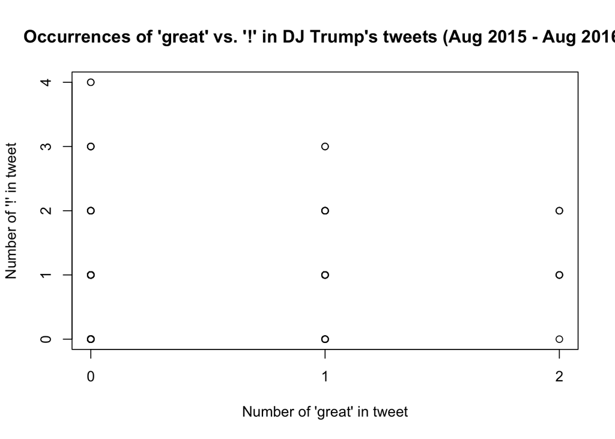

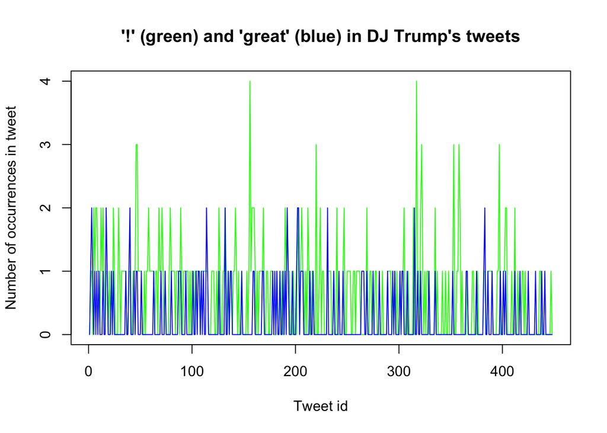

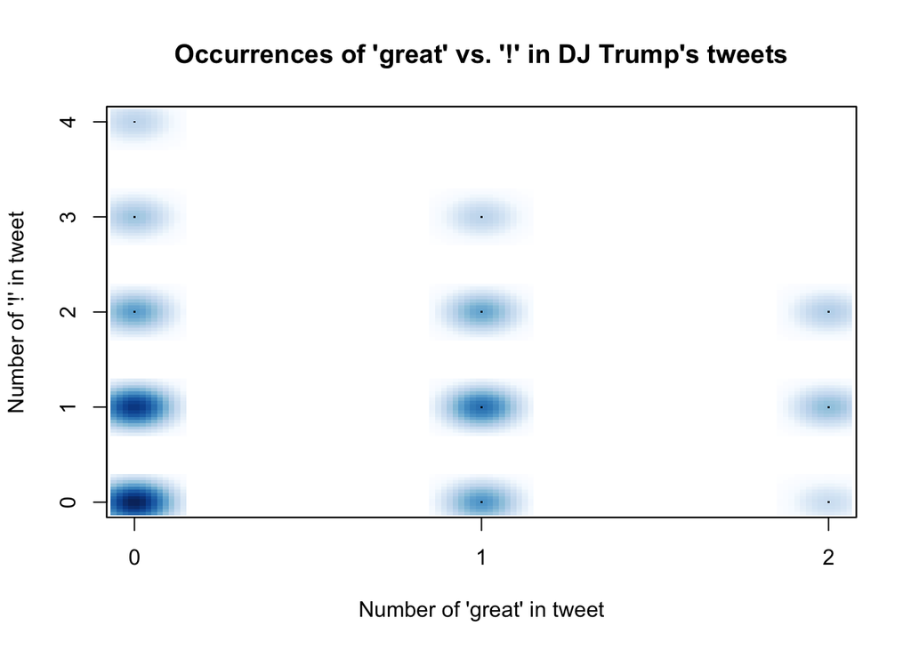

*Nota:* the darker the dot, the more observations (e.g. (0,0): 192 obs., (0,4): 2 obs.).

### 6. Add a picture

[figure not shown]

Quite an emphatic bird